# Introduction

Today we'll dive deep into a dataset all about LEGO. From the dataset we can ask whole bunch of interesting questions about the history of the LEGO company, their product offering, and which LEGO set ultimately rules them all:

- What is the most enormous LEGO set ever created and how many parts did it have?
- How did the LEGO company start out? In which year were the first LEGO sets released and how many sets did the company sell when it first launched?
- Which LEGO theme has the most sets? Is it one of LEGO's own themes like Ninjago or a theme they licensed liked Harry Potter or Marvel Superheroes?
- When did the LEGO company really expand its product offering? Can we spot a change in the company strategy based on how many themes and sets did it released year-on-year?
- Did LEGO sets grow in size and complexity over time? Do older LEGO sets tend to have more or fewer parts than newer sets?

**Data Source**

[Rebrickable](https://rebrickable.com/downloads/) has compiled data on all the LEGO pieces in existence. I recommend you use download the .csv files provided in this lesson.

# Import Statements

```python
import pandas as pd
```

```python
import matplotlib.pyplot as plt
```

[figure not shown]

### Section Headings

# Data Exploration

**Challenge**: How many different colours does the LEGO company produce? Read the colors.csv file in the data folder and find the total number of unique colours. Try using the [.nunique() method](https://pandas.pydata.org/pandas-docs/stable/reference/api/pandas.DataFrame.nunique.html?highlight=nunique#pandas.DataFrame.nunique) to accomplish this.

```python
clr = pd.read_csv('data/colors.csv')
```

```python
clr.head()
```

|  | id | name | rgb | is_trans |
| --- | --- | --- | --- | --- |
| 0 | -1 | Unknown | 0033B2 | f |
| 1 | 0 | Black | 05131D | f |
| 2 | 1 | Blue | 0055BF | f |
| 3 | 2 | Green | 237841 | f |
| 4 | 3 | Dark Turquoise | 008F9B | f |

```python
clr['name'].nunique()
```

```
135
```

**Challenge**: Find the number of transparent colours where `is_trans == 't'` versus the number of opaque colours where `is_trans == 'f'`. See if you can accomplish this in two different ways.

```python
clr['is_trans'].value_counts()
```

```
is_trans
f    107
t     28
Name: count, dtype: int64
```

```python
clr.groupby('is_trans').count()
```

| is_trans | id | name | rgb |
| --- | --- | --- | --- |
| f | 107 | 107 | 107 |
| t | 28 | 28 | 28 |

**Challenge**: Change this into an h3 section heading: Understanding LEGO Themes vs. LEGO Sets

Walk into a LEGO store and you will see their products organised by theme. Their themes include Star Wars, Batman, Harry Potter and many more.

**Challenge**: Display this image: https://i.imgur.com/aKcwkSx.png

A lego set is a particular box of LEGO or product. Therefore, a single theme typically has many different sets.

**Challenge**: Display this image https://i.imgur.com/whB1olq.png

The `sets.csv` data contains a list of sets over the years and the number of parts that each of these sets contained.

**Challenge**: Read the sets.csv data and take a look at the first and last couple of rows.

# **Understanding LEGO Themes vs. LEGO Sets**

### Walk into a LEGO store and you will see their products organised by theme. Their themes include Star Wars, Batman, Harry Potter and many more.

[figure not shown]

**Challenge**: In which year were the first LEGO sets released and what were these sets called?

## A lego **set** is a particular box of LEGO or product. Therefore, a single theme typically has many different sets.

[figure not shown]

```python
set=pd.read_csv('data/sets.csv')
```

```python
set.head()
```

|  | set_num | name | year | theme_id | num_parts |
| --- | --- | --- | --- | --- | --- |
| 0 | 001-1 | Gears | 1965 | 1 | 43 |
| 1 | 0011-2 | Town Mini-Figures | 1978 | 84 | 12 |
| 2 | 0011-3 | Castle 2 for 1 Bonus Offer | 1987 | 199 | 0 |
| 3 | 0012-1 | Space Mini-Figures | 1979 | 143 | 12 |
| 4 | 0013-1 | Space Mini-Figures | 1979 | 143 | 12 |

**Challenge**: How many different sets did LEGO sell in their first year? How many types of LEGO products were on offer in the year the company started?

```python
set.sort_values('year').head()
```

|  | set_num | name | year | theme_id | num_parts |
| --- | --- | --- | --- | --- | --- |
| 9521 | 700.1-1 | Extra-Large Gift Set (ABB) | 1949 | 365 | 142 |
| 9534 | 700.2-1 | Large Gift Set (ABB) | 1949 | 365 | 178 |
| 9539 | 700.3-1 | Medium Gift Set (ABB) | 1949 | 365 | 142 |
| 9544 | 700.A-1 | Small Brick Set (ABB) | 1949 | 371 | 24 |
| 9545 | 700.B-1 | Small Doors and Windows Set (ABB) | 1949 | 371 | 12 |

```python
set[set['year']==1949].count()
```

```
set_num      5
name         5
year         5
theme_id     5
num_parts    5
dtype: int64
```

**Challenge**: Find the top 5 LEGO sets with the most number of parts.

```python
set.sort_values('num_parts',ascending=False).head()
```

|  | set_num | name | year | theme_id | num_parts |
| --- | --- | --- | --- | --- | --- |
| 15004 | BIGBOX-1 | The Ultimate Battle for Chima | 2015 | 571 | 9987 |
| 11183 | 75192-1 | UCS Millennium Falcon | 2017 | 171 | 7541 |
| 10551 | 71043-1 | Hogwarts Castle | 2018 | 246 | 6020 |
| 295 | 10256-1 | Taj Mahal | 2017 | 673 | 5923 |
| 221 | 10189-1 | Taj Mahal | 2008 | 673 | 5922 |

**Challenge**: Use `.groupby()` and `.count()` to show the number of LEGO sets released year-on-year. How do the number of sets released in 1955 compare to the number of sets released in 2019?

```python
sets_by_year=set.groupby('year').count()['set_num']
sets_by_year.head()
```

```
year
1949     5
1950     6
1953     4
1954    14
1955    28
Name: set_num, dtype: int64
```

#### **Challenge**: Show the number of LEGO releases on a line chart using Matplotlib.

Note that the .csv file is from late 2020, so to plot the full calendar years, you will have to exclude some data from your chart. Can you use the slicing techniques covered in Day 21 to avoid plotting the last two years? The same syntax will work on Pandas DataFrames.

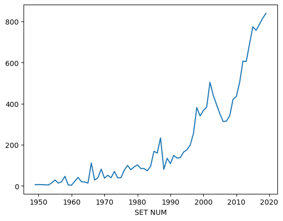

```python
plt.plot(sets_by_year.index[:-2],sets_by_year.values[:-2])
plt.xlabel('YEAR')
plt.xlabel('SET NUM')
```

### Aggregate Data with the Python .agg() Function

Let's work out the number of different themes shipped by year. This means we have to count the number of unique theme_ids per calendar year.

This means we have to group the data by year and then count the number of unique theme_ids for that year.

Number of Themes per Calendar Year

We can accomplish this by chaining the .groupby() and the .agg() functions together:

```python
set.head()
```

|  | set_num | name | year | theme_id | num_parts |
| --- | --- | --- | --- | --- | --- |
| 0 | 001-1 | Gears | 1965 | 1 | 43 |
| 1 | 0011-2 | Town Mini-Figures | 1978 | 84 | 12 |
| 2 | 0011-3 | Castle 2 for 1 Bonus Offer | 1987 | 199 | 0 |
| 3 | 0012-1 | Space Mini-Figures | 1979 | 143 | 12 |
| 4 | 0013-1 | Space Mini-Figures | 1979 | 143 | 12 |

```python
themes_by_year=set.groupby('year').agg({'theme_id':pd.Series.nunique})
```

```python
themes_by_year.head()
```

| year | theme_id |
| --- | --- |
| 1949 | 2 |
| 1950 | 1 |
| 1953 | 2 |
| 1954 | 2 |
| 1955 | 4 |

```python
themes_by_year.rename(columns={'theme_id':'nr_themes'},inplace=True)
themes_by_year.head()
```

| year | nr_themes |
| --- | --- |
| 1949 | 2 |
| 1950 | 1 |
| 1953 | 2 |
| 1954 | 2 |
| 1955 | 4 |

Note, the .agg() method takes a dictionary as an argument. In this dictionary, we specify which operation we'd like to apply to each column. In our case, we just want to calculate the number of unique entries in the theme_id column by using our old friend, the .nunique() method.

**Challenge**: Plot the number of themes released by year on a line chart. Only include the full calendar years (i.e., exclude 2020 and 2021).

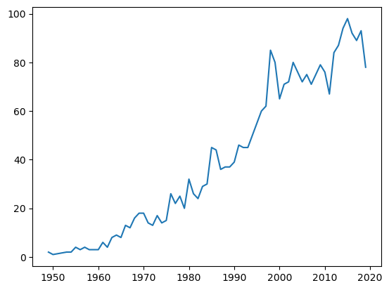

```python
plt.plot(themes_by_year.index[:-2],themes_by_year.nr_themes[:-2])
```

### Line Charts with Two Seperate Axes

```python
sets_by_year.head()
```

```
year
1949     5
1950     6
1953     4
1954    14
1955    28
Name: set_num, dtype: int64
```

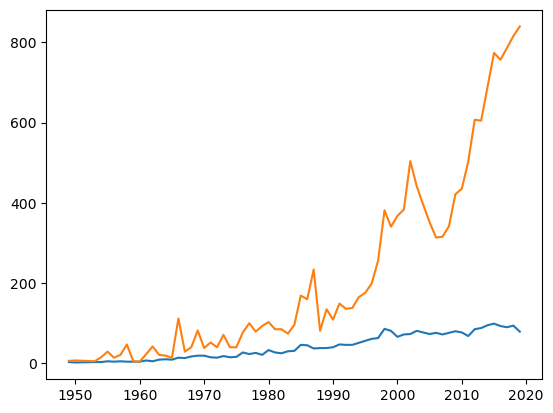

```python
plt.plot(themes_by_year.index[:-2],themes_by_year.nr_themes[:-2])
plt.plot(sets_by_year.index[:-2],sets_by_year.values[:-2])
```

## **Two Separate Axes**

We need to be able to configure and plot our data on two separate axes on the same chart. This involves getting hold of an axis object from Matplotlib.

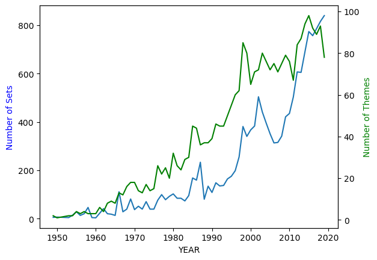

```python
ax1 = plt.gca()
ax2 = plt.twinx()

ax1.plot(sets_by_year.index[:-2],sets_by_year.values[:-2])
ax2.plot(themes_by_year.index[:-2],themes_by_year.nr_themes[:-2],'g')

ax1.set_xlabel("YEAR")
ax1.set_ylabel("Number of Sets",color='b')
ax2.set_ylabel("Number of Themes",color='g')
```

```python
set.head()
```

|  | set_num | name | year | theme_id | num_parts |
| --- | --- | --- | --- | --- | --- |
| 0 | 001-1 | Gears | 1965 | 1 | 43 |
| 1 | 0011-2 | Town Mini-Figures | 1978 | 84 | 12 |
| 2 | 0011-3 | Castle 2 for 1 Bonus Offer | 1987 | 199 | 0 |
| 3 | 0012-1 | Space Mini-Figures | 1979 | 143 | 12 |
| 4 | 0013-1 | Space Mini-Figures | 1979 | 143 | 12 |

**Challenge**: Use the `.groupby()` and `.agg()` function together to figure out the average number of parts per set. How many parts did the average LEGO set released in 1954 compared to say, 2017?

```python
parts_per_set = set.groupby('year').agg({'num_parts':pd.Series.mean})
parts_per_set.rename(columns={'num_parts':'average_num_parts'},inplace=True)
parts_per_set.head()
```

| year | average_num_parts |
| --- | --- |
| 1949 | 99.600000 |
| 1950 | 1.000000 |
| 1953 | 13.500000 |
| 1954 | 12.357143 |
| 1955 | 36.607143 |

### Scatter Plots in Matplotlib

**Challenge**: Has the size and complexity of LEGO sets increased over time based on the number of parts? Plot the average number of parts over time using a Matplotlib scatter plot. See if you can use the [scatter plot documentation](https://matplotlib.org/3.1.0/api/_as_gen/matplotlib.pyplot.scatter.html) before I show you the solution. Do you spot a trend in the chart?

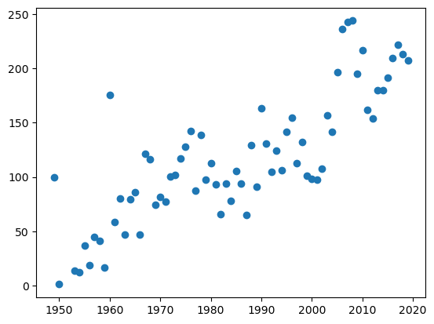

```python
plt.scatter(parts_per_set.index[:-2],parts_per_set.average_num_parts[:-2])
```

### Number of Sets per LEGO Theme

LEGO has licensed many hit franchises from Harry Potter to Marvel Super Heros to many others. But which theme has the largest number of individual sets?

```python
set_theme_count=set['theme_id'].value_counts()
set_theme_count[:5]
```

```
theme_id
158    753
501    656
494    398
435    356
503    329
Name: count, dtype: int64
```

**Challenge** Use what you know about HTML markup and tags to display the database schema: https://i.imgur.com/Sg4lcjx.png

[figure not shown]

### Working with a Relational Database

What is a database schema? A schema is just how the database is organised. Many relational databases, such as our LEGO data, is split into individual tables. We have separate tables for the colours, the sets and the thems. With a relational database, the tables are linked to each other through their keys.

### Database Schemas, Foreign Keys and Merging DataFrames

The themes.csv file has the actual theme names. The sets .csv has `theme_ids` which link to the `id` column in the themes.csv.

```python
themes=pd.read_csv('data/themes.csv')
```

```python
themes.head()
```

|  | id | name | parent_id |
| --- | --- | --- | --- |
| 0 | 1 | Technic | NaN |
| 1 | 2 | Arctic Technic | 1.0 |
| 2 | 3 | Competition | 1.0 |
| 3 | 4 | Expert Builder | 1.0 |
| 4 | 5 | Model | 1.0 |

**Challenge**: Explore the themes.csv. How is it structured? Search for the name 'Star Wars'. How many `id`s correspond to this name in the themes.csv? Now use these `id`s and find the corresponding the sets in the sets.csv (Hint: you'll need to look for matches in the `theme_id` column)

```python
themes[themes.name=='Star Wars']
```

|  | id | name | parent_id |
| --- | --- | --- | --- |
| 17 | 18 | Star Wars | 1.0 |
| 150 | 158 | Star Wars | NaN |
| 174 | 209 | Star Wars | 207.0 |
| 211 | 261 | Star Wars | 258.0 |

```python
set.head()
```

|  | set_num | name | year | theme_id | num_parts |
| --- | --- | --- | --- | --- | --- |
| 0 | 001-1 | Gears | 1965 | 1 | 43 |
| 1 | 0011-2 | Town Mini-Figures | 1978 | 84 | 12 |
| 2 | 0011-3 | Castle 2 for 1 Bonus Offer | 1987 | 199 | 0 |
| 3 | 0012-1 | Space Mini-Figures | 1979 | 143 | 12 |
| 4 | 0013-1 | Space Mini-Figures | 1979 | 143 | 12 |

```python
set[set.theme_id==18]
```

|  | set_num | name | year | theme_id | num_parts |
| --- | --- | --- | --- | --- | --- |
| 8786 | 65081-1 | R2-D2 / C-3PO Droid Collectors Set | 2002 | 18 | 1 |
| 12051 | 8000-1 | Pit Droid | 2000 | 18 | 223 |
| 12058 | 8001-1 | Battle Droid | 2000 | 18 | 336 |
| 12066 | 8002-1 | Destroyer Droid | 2000 | 18 | 567 |
| 12071 | 8007-1 | C-3PO | 2001 | 18 | 339 |
| 12072 | 8008-1 | Stormtrooper | 2001 | 18 | 360 |
| 12073 | 8009-1 | R2-D2 | 2002 | 18 | 239 |
| 12074 | 8010-1 | Darth Vader | 2002 | 18 | 388 |
| 12081 | 8011-1 | Jango Fett | 2002 | 18 | 425 |
| 12083 | 8012-1 | Super Battle Droid | 2002 | 18 | 378 |
| 15273 | K8008-1 | Darth Vader / Stormtrooper Kit | 2002 | 18 | 0 |

```python
set[set.theme_id==209]
```

|  | set_num | name | year | theme_id | num_parts |
| --- | --- | --- | --- | --- | --- |
| 11013 | 75023-1 | Star Wars Advent Calendar 2013 | 2013 | 209 | 254 |
| 11046 | 75056-1 | Star Wars Advent Calendar 2014 | 2014 | 209 | 273 |
| 11080 | 75097-1 | Star Wars Advent Calendar 2015 | 2015 | 209 | 291 |
| 11131 | 75146-1 | Star Wars Advent Calendar 2016 | 2016 | 209 | 282 |
| 11173 | 75184-1 | Star Wars Advent Calendar 2017 | 2017 | 209 | 309 |
| 11206 | 75213-1 | Star Wars Advent Calendar 2018 | 2018 | 209 | 307 |
| 11245 | 75245-1 | Star Wars Advent Calendar 2019 | 2019 | 209 | 280 |
| 11281 | 75279-1 | Star Wars Advent Calendar 2020 | 2020 | 209 | 312 |
| 12019 | 7958-1 | Star Wars Advent Calendar 2011 | 2011 | 209 | 267 |
| 14352 | 9509-1 | Star Wars Advent Calendar 2012 | 2012 | 209 | 235 |

```python
set[set.theme_id==158]
```

|  | set_num | name | year | theme_id | num_parts |
| --- | --- | --- | --- | --- | --- |
| 850 | 11912-1 | Star Wars: Build Your Own Adventure | 2016 | 158 | 73 |
| 855 | 11920-1 | Parts for Star Wars Build Your Own Adventure: ... | 2019 | 158 | 70 |
| 1717 | 20006-1 | Clone Turbo Tank - Mini | 2008 | 158 | 64 |
| 1728 | 20007-1 | Republic Attack Cruiser - Mini | 2009 | 158 | 84 |
| 1738 | 20009-1 | AT-TE Walker - Mini | 2009 | 158 | 94 |
| ... | ... | ... | ... | ... | ... |
| 15686 | VP-4 | Star Wars Co-Pack of 7101 7111 and 7171 | 2000 | 158 | 0 |
| 15689 | VP-8 | Star Wars Co-Pack of 7130 and 7150 | 2000 | 158 | 0 |
| 15707 | XWING-1 | Mini X-Wing Fighter | 2019 | 158 | 60 |
| 15708 | XWING-2 | X-Wing Trench Run | 2019 | 158 | 52 |
| 15709 | YODACHRON-1 | Yoda Chronicles Promotional Set | 2013 | 158 | 413 |

753 rows × 5 columns

```python
set[set.theme_id==261]
```

|  | set_num | name | year | theme_id | num_parts |
| --- | --- | --- | --- | --- | --- |
| 14630 | 9748-1 | Droid Developer Kit | 1999 | 261 | 658 |
| 14636 | 9754-1 | Dark Side Developers Kit | 2000 | 261 | 578 |

### Merging (i.e., Combining) DataFrames based on a Key

Let's use the .merge() method to combine two separate DataFrames into one. The merge method works on columns with the same name in both DataFrames.

```python
set_theme_count = pd.DataFrame({'id':set_theme_count.index,
                                'set_count':set_theme_count.values})
```

```python
set_theme_count.head()
```

|  | id | set_count |
| --- | --- | --- |
| 0 | 158 | 753 |
| 1 | 501 | 656 |
| 2 | 494 | 398 |
| 3 | 435 | 356 |
| 4 | 503 | 329 |

## The Pandas .merge() function

To .merge() two DataFrame along a particular column, we need to provide our two DataFrames and then the column name on which to merge. This is why we set on='id'. Both our set_theme_count and our themes DataFrames have a column with this name.

merged_df = pd.merge(set_theme_count, themes, on='id')

```python
merged_df = pd.merge(set_theme_count,themes,on ='id')
```

```python
merged_df[:3]
```

|  | id | set_count | name | parent_id |
| --- | --- | --- | --- | --- |
| 0 | 158 | 753 | Star Wars | NaN |
| 1 | 501 | 656 | Gear | NaN |
| 2 | 494 | 398 | Friends | NaN |

Creating a Bar Chart

Matplotlib can create almost any chart imaginable with very few lines of code. Using .bar() we can provide our theme names and the number of sets. This is what we get:

```
<BarContainer object of 10 artists>
```

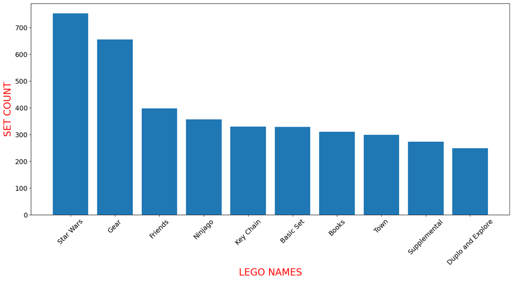

```python
plt.figure(figsize=(18,8))
plt.xticks(fontsize=14,rotation=45)
plt.yticks(fontsize=14)
plt.xlabel('LEGO NAMES',fontsize=20,color='r')
plt.ylabel('SET COUNT',fontsize=20,color='r')
plt.bar(merged_df.name[:10],merged_df.set_count[:10])
```

### In this lesson we looked at how to:

use HTML Markdown in Notebooks, such as section headings # and how to embed images with the

[figure not shown]

tag.

combine the groupby() and count() functions to aggregate data

use the .value_counts() function

slice DataFrames using the square bracket notation e.g., df[:-2] or df[:10]

use the .agg() function to run an operation on a particular column

rename() columns of DataFrames

create a line chart with two separate axes to visualise data that have different scales.

create a scatter plot in Matplotlib

work with tables in a relational database by using primary and foreign keys

.merge() DataFrames along a particular column

create a bar chart with Matplotlib